# Rweka manual to greek

stkarlos

September 10, 2015

Το τρέχων αρχείο αποτελεί μία συνεισφορά προς το ellak και αποτελείται από ορισμένα χρήσιμα παραδείγματα για το πακέτο RWeka μαζί με ορισμένες χρήσιμες οπτικοπιήσεις δεδομένων με τη βοήθεια και άλλων πακέτων, για την παρατήρηση ορισμένων κρίσιμων χαρακτηριστικών και συμπεριφορών διάφορων ταξινομητών σε προβλήματα ανεύρεσης γνώσης.

Το συγκεκριμένο αρχείο αποτελςεί ένα **R Markdown** έγγραφο. Το Markdown αποτελεί έναν απλό τρόπο σύνταξης και μορφοποίησης κειμένων για την έκδοση **HTML, PDF, και MS Word** αρχείων. Για περισσότερες πληροφορίες για τη χρήση του R Markdown μπορείτε να δείτε στο http://rmarkdown.rstudio.com.

#### Το πρώτο παράδειγμα αφορά την εκτίμηση ενός Weka ταξινομητή

##### Η ανάγνωση των αρχείων γίνεται μέσω της read.arff.

```r
require(RWeka)
## Χρήσητου dataset weather.nominal
w <- read.arff(system.file("arff","weather.nominal.arff",
                package = "RWeka"))

# Περίληψη και πληροφόρηση των περιεχομένων του weather.nominal
summary(w)
```

```
##      outlook  temperature   humidity   windy          play
##  sunny   :5   hot :4      high  :7   Mode :logical   yes:9
##  overcast:4   mild:6      normal:7   FALSE:8         no :5
##  rainy   :5   cool:4                 TRUE :6
##                                      NA's :0
```

```r
## Δημιουργία ενός δένδρου απόφασης j48
m <- J48( play ~ ., data = w )
```

##### Χρήσιμες πληροφορίες για το δένδρο απόφασης και εκτίμηση του ταξινομητή μέσω 10-cross validation.

```r
m
```

```
## J48 pruned tree
## ------------------
##
## outlook = sunny
## |   humidity = high: no (3.0)
## |   humidity = normal: yes (2.0)
## outlook = overcast: yes (4.0)
## outlook = rainy
## |   windy = FALSE: yes (3.0)
## |   windy = TRUE: no (2.0)
##
## Number of Leaves  :  5
##
## Size of the tree :   8
```

```r
## Χρήση 10-cross validation με συγκεκριμένο πίνακα κόστους.
e <- evaluate_Weka_classifier(m, cost = matrix(c(0,2,1,0), ncol = 2),
                                        numFolds = 10, complexity = TRUE,
                                        seed = 123, class = TRUE)

# Οπτικοποίηση πληροφοριών
e
```

```
## === 10 Fold Cross Validation ===
##
## === Summary ===
##
## Correctly Classified Instances           5               35.7143 %
## Incorrectly Classified Instances         9               64.2857 %
## Kappa statistic                         -0.3404
## Total Cost                              13
## Average Cost                             0.9286
## K&B Relative Info Score               -310.2048 %
## K&B Information Score                   -2.8486 bits     -0.2035 bits/instance
## Class complexity | order 0              13.7612 bits      0.9829 bits/instance
## Class complexity | scheme             4305.1699 bits    307.5121 bits/instance
## Complexity improvement     (Sf)      -4291.4087 bits   -306.5292 bits/instance
## Mean absolute error                      0.5417
## Root mean squared error                  0.6854
## Relative absolute error                113.75   %
## Root relative squared error            138.9193 %
## Coverage of cases (0.95 level)          71.4286 %
## Mean rel. region size (0.95 level)      67.8571 %
## Total Number of Instances               14
##
## === Detailed Accuracy By Class ===
##
##                  TP Rate  FP Rate  Precision  Recall   F-Measure  MCC      ROC Area  PRC Area  Class
##                  0.444    0.800    0.500      0.444    0.471      -0.344   0.478     0.703     yes
##                  0.200    0.556    0.167      0.200    0.182      -0.344   0.478     0.360     no
## Weighted Avg.    0.357    0.713    0.381      0.357    0.367      -0.344   0.478     0.581
##
## === Cost Matrix ===
##
##  0 1
##  2 0
##
## === Confusion Matrix ===
##
##  a b   <-- classified as
##  4 5 | a = yes
##  4 1 | b = no
```

```r
summary(e)
```

```
##                   Length Class  Mode
## string             1     -none- character
## details            8     -none- numeric
## detailsCost        1     -none- numeric
## detailsComplexity  4     -none- numeric
## detailsClass      12     -none- numeric
## confusionMatrix    4     -none- numeric
```

```r
e$details
```

```
##               pctCorrect             pctIncorrect          pctUnclassified
##               35.7142857               64.2857143                0.0000000
##                    kappa        meanAbsoluteError     rootMeanSquaredError
##               -0.3404255                0.5416667                0.6853773
##    relativeAbsoluteError rootRelativeSquaredError
##              113.7500000              138.9192548
```

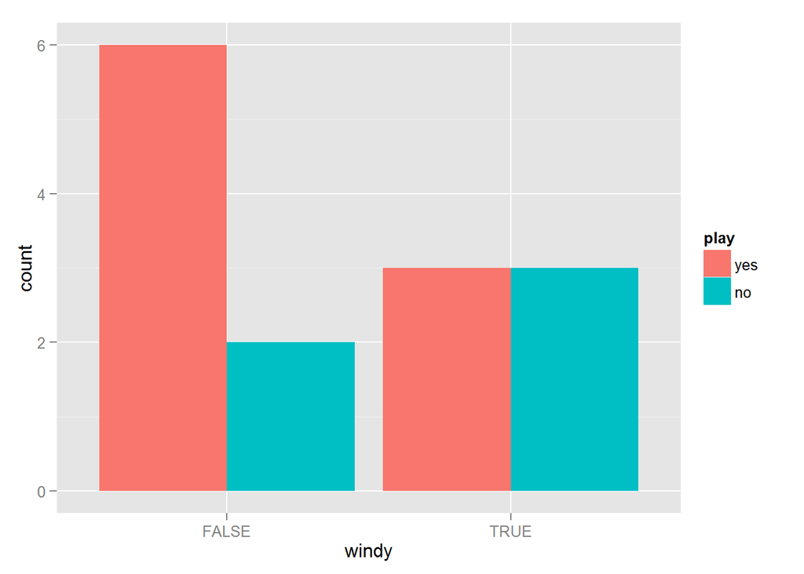

```r
require(ggplot2)
# windy vs play
ggplot(w, aes( x = windy, fill = play )) + geom_bar(position = "dodge")
```

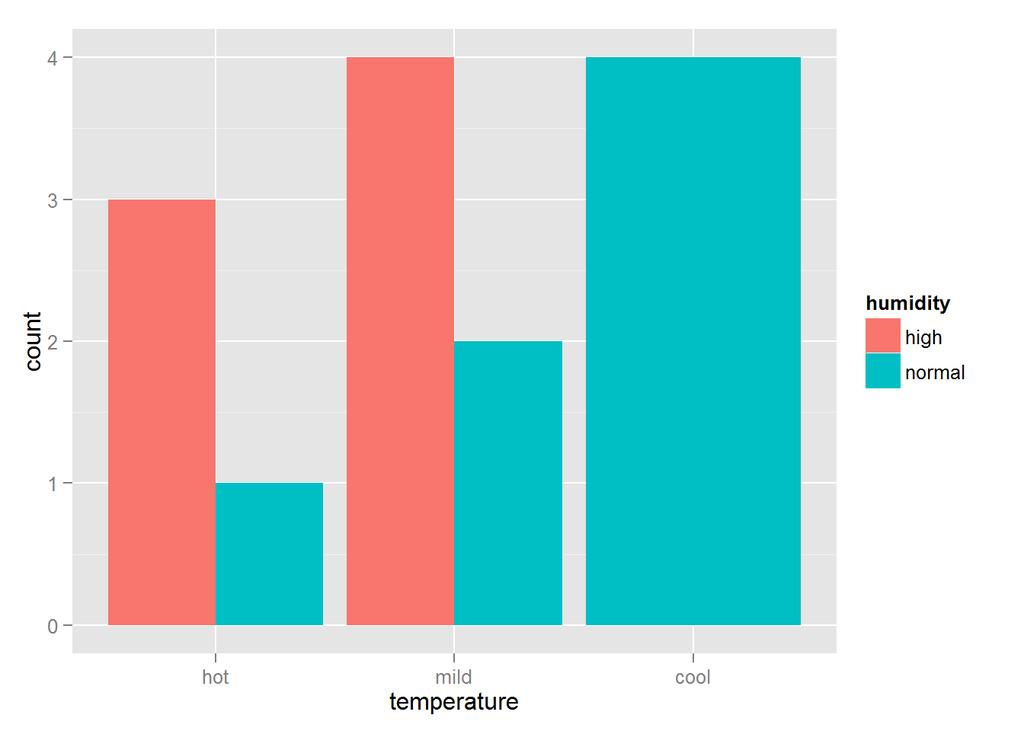

```r
# temperature vs humidity
ggplot(w, aes( x = temperature , fill = humidity )) + geom_bar(position = "dodge")
```

#### Το δεύτερο παράδειγμα αφορά την εξαγωγή κανόνων συσχέτισης για το σύνολο δεδομένων contact-lenses

```r
x <- read.arff(system.file("arff", "contact-lenses.arff",
                package = "RWeka"))

## Κλήση του Apriori αλγορίθμου με τις τυπικές παράμετρους.
Apriori(x)
```

```
##
## Apriori
## =======
##
## Minimum support: 0.2 (5 instances)
## Minimum metric <confidence>: 0.9
## Number of cycles performed: 16
##
## Generated sets of large itemsets:
##
## Size of set of large itemsets L(1): 11
##
## Size of set of large itemsets L(2): 21
##
## Size of set of large itemsets L(3): 6
##
## Best rules found:
##
##  1. tear-prod-rate=reduced 12 ==> contact-lenses=none 12    <conf:(1)> lift:(1.6) lev:(0.19) [4] conv:(4.5)
##  2. spectacle-prescrip=myope tear-prod-rate=reduced 6 ==> contact-lenses=none 6    <conf:(1)> lift:(1.6) lev:(0.09) [2] conv:(2.25)
##  3. spectacle-prescrip=hypermetrope tear-prod-rate=reduced 6 ==> contact-lenses=none 6    <conf:(1)> lift:(1.6) lev:(0.09) [2] conv:(2.25)
##  4. astigmatism=no tear-prod-rate=reduced 6 ==> contact-lenses=none 6    <conf:(1)> lift:(1.6) lev:(0.09) [2] conv:(2.25)
##  5. astigmatism=yes tear-prod-rate=reduced 6 ==> contact-lenses=none 6    <conf:(1)> lift:(1.6) lev:(0.09) [2] conv:(2.25)
##  6. contact-lenses=soft 5 ==> astigmatism=no 5    <conf:(1)> lift:(2) lev:(0.1) [2] conv:(2.5)
##  7. contact-lenses=soft 5 ==> tear-prod-rate=normal 5    <conf:(1)> lift:(2) lev:(0.1) [2] conv:(2.5)
##  8. tear-prod-rate=normal contact-lenses=soft 5 ==> astigmatism=no 5    <conf:(1)> lift:(2) lev:(0.1) [2] conv:(2.5)
##  9. astigmatism=no contact-lenses=soft 5 ==> tear-prod-rate=normal 5    <conf:(1)> lift:(2) lev:(0.1) [2] conv:(2.5)
## 10. contact-lenses=soft 5 ==> astigmatism=no tear-prod-rate=normal 5    <conf:(1)> lift:(4) lev:(0.16) [3] conv:(3.75)
```

```r
## Επιλογή για επιστροφή των καλύτερων 20 κανόνων ως προς το δείκτη εμπιστοσύνης.
Apriori(x, Weka_control(N = 20))
```

```
##
## Apriori
## =======
##
## Minimum support: 0.1 (2 instances)
## Minimum metric <confidence>: 0.9
## Number of cycles performed: 18
##
## Generated sets of large itemsets:
##
## Size of set of large itemsets L(1): 12
##
## Size of set of large itemsets L(2): 49
##
## Size of set of large itemsets L(3): 84
##
## Size of set of large itemsets L(4): 26
##
## Best rules found:
##
##  1. tear-prod-rate=reduced 12 ==> contact-lenses=none 12    <conf:(1)> lift:(1.6) lev:(0.19) [4] conv:(4.5)
##  2. spectacle-prescrip=myope tear-prod-rate=reduced 6 ==> contact-lenses=none 6    <conf:(1)> lift:(1.6) lev:(0.09) [2] conv:(2.25)
##  3. spectacle-prescrip=hypermetrope tear-prod-rate=reduced 6 ==> contact-lenses=none 6    <conf:(1)> lift:(1.6) lev:(0.09) [2] conv:(2.25)
##  4. astigmatism=no tear-prod-rate=reduced 6 ==> contact-lenses=none 6    <conf:(1)> lift:(1.6) lev:(0.09) [2] conv:(2.25)
##  5. astigmatism=yes tear-prod-rate=reduced 6 ==> contact-lenses=none 6    <conf:(1)> lift:(1.6) lev:(0.09) [2] conv:(2.25)
##  6. contact-lenses=soft 5 ==> astigmatism=no 5    <conf:(1)> lift:(2) lev:(0.1) [2] conv:(2.5)
##  7. contact-lenses=soft 5 ==> tear-prod-rate=normal 5    <conf:(1)> lift:(2) lev:(0.1) [2] conv:(2.5)
##  8. tear-prod-rate=normal contact-lenses=soft 5 ==> astigmatism=no 5    <conf:(1)> lift:(2) lev:(0.1) [2] conv:(2.5)
##  9. astigmatism=no contact-lenses=soft 5 ==> tear-prod-rate=normal 5    <conf:(1)> lift:(2) lev:(0.1) [2] conv:(2.5)
## 10. contact-lenses=soft 5 ==> astigmatism=no tear-prod-rate=normal 5    <conf:(1)> lift:(4) lev:(0.16) [3] conv:(3.75)
## 11. contact-lenses=hard 4 ==> astigmatism=yes 4    <conf:(1)> lift:(2) lev:(0.08) [2] conv:(2)
## 12. contact-lenses=hard 4 ==> tear-prod-rate=normal 4    <conf:(1)> lift:(2) lev:(0.08) [2] conv:(2)
## 13. age=young contact-lenses=none 4 ==> tear-prod-rate=reduced 4    <conf:(1)> lift:(2) lev:(0.08) [2] conv:(2)
## 14. age=young tear-prod-rate=reduced 4 ==> contact-lenses=none 4    <conf:(1)> lift:(1.6) lev:(0.06) [1] conv:(1.5)
## 15. age=pre-presbyopic tear-prod-rate=reduced 4 ==> contact-lenses=none 4    <conf:(1)> lift:(1.6) lev:(0.06) [1] conv:(1.5)
## 16. age=presbyopic tear-prod-rate=reduced 4 ==> contact-lenses=none 4    <conf:(1)> lift:(1.6) lev:(0.06) [1] conv:(1.5)
## 17. tear-prod-rate=normal contact-lenses=hard 4 ==> astigmatism=yes 4    <conf:(1)> lift:(2) lev:(0.08) [2] conv:(2)
## 18. astigmatism=yes contact-lenses=hard 4 ==> tear-prod-rate=normal 4    <conf:(1)> lift:(2) lev:(0.08) [2] conv:(2)
## 19. contact-lenses=hard 4 ==> astigmatism=yes tear-prod-rate=normal 4    <conf:(1)> lift:(4) lev:(0.13) [3] conv:(3)
## 20. spectacle-prescrip=myope contact-lenses=hard 3 ==> astigmatism=yes 3    <conf:(1)> lift:(2) lev:(0.06) [1] conv:(1.5)
```

#### Το επόμενο παράδειγμα αφορά την εκτίμηση του δείκτη Gain για τη διπασπαση του δένδρου.

```r
# Πληροφόρηση για τις κατηγορίες του συνόλου δεδομένων iris
summary(iris)
```

```
##   Sepal.Length    Sepal.Width     Petal.Length    Petal.Width
##  Min.   :4.300   Min.   :2.000   Min.   :1.000   Min.   :0.100
##  1st Qu.:5.100   1st Qu.:2.800   1st Qu.:1.600   1st Qu.:0.300
##  Median :5.800   Median :3.000   Median :4.350   Median :1.300
##  Mean   :5.843   Mean   :3.057   Mean   :3.758   Mean   :1.199
##  3rd Qu.:6.400   3rd Qu.:3.300   3rd Qu.:5.100   3rd Qu.:1.800
##  Max.   :7.900   Max.   :4.400   Max.   :6.900   Max.   :2.500
##        Species
##  setosa    :50
##  versicolor:50
##  virginica :50
##
##
##
```

```r
# Υπολογισμός του κέρδους πληροφορίας και δείκτη κέρδους για κάθε για την κλάση πρόβλεψης του συνόλου δεδομένων (Species)
InfoGainAttributeEval(Species ~ . , data = iris)
```

```
## Sepal.Length  Sepal.Width Petal.Length  Petal.Width
##    0.6982615    0.3855963    1.4180030    1.3784027
```

```r
GainRatioAttributeEval(Species ~ . , data = iris)
```

```
## Sepal.Length  Sepal.Width Petal.Length  Petal.Width
##    0.3811740    0.2472972    0.7339960    0.8713692
```

#### Παραδείγματα υλοποίησης μοντέλων προσέγγισης μέσω των αλγορίθμων μάθησης του Weka.

```r
## Παράδειγμα εφαρμογής Linear regression - Γραμμικής Παλινδρόμησης
## Χρήση του συνόλου δεδομένων 'mtcars' το οποίο περιέχεται στο περιβλαλλον της R
LinearRegression(mpg ~ ., data = mtcars)
```

```
##
## Linear Regression Model
##
## mpg =
##
##      -3.9165 * wt +
##       1.2259 * qsec +
##       2.9358 * am +
##       9.6178
```

```r
## Σύγκριση με τη συνάρτηση step της  R για την προσέγγιση ενός μοντέλου περιγραφής:
step(lm(mpg ~ ., data = mtcars), trace = 0)
```

```
##
## Call:
## lm(formula = mpg ~ wt + qsec + am, data = mtcars)
##
## Coefficients:
## (Intercept)           wt         qsec           am
##       9.618       -3.917        1.226        2.936
```

```r
## Χρήση του συνόλου δεδομένων 'chickwts' το οποίο περιέχεται στο περιβλαλλον της R
LinearRegression(weight ~ feed, data = chickwts)
```

```
##
## Linear Regression Model
##
## weight =
##
##      73.4538 * feed=linseed,soybean,meatmeal,casein,sunflower +
##      43.2552 * feed=meatmeal,casein,sunflower +
##      49.3409 * feed=casein,sunflower +
##     160.2
```

```r
## Παράδειγμα εφαρμογής Logistic regression:
## Χρήση του συνόλου δεδομένων 'infert' το οποίο περιέχεται στο περιβλαλλον της R
STATUS <- factor(infert$case, labels = c("control", "case"))
Logistic(STATUS ~ spontaneous + induced, data = infert)
```

```
## Logistic Regression with ridge parameter of 1.0E-8
## Coefficients...
##                  Class
## Variable       control
## ======================
## spontaneous    -1.1972
## induced        -0.4181
## Intercept       1.7078
##
##
## Odds Ratios...
##                  Class
## Variable       control
## ======================
## spontaneous      0.302
## induced         0.6583
```

```r
## Σύγκριση με τη συνάρτηση gml (Generalized Linear Models) της  R για την προσέγγιση ενός μοντέλου περιγραφής
glm(STATUS ~ spontaneous + induced, data = infert, family = binomial())
```

```
##
## Call:  glm(formula = STATUS ~ spontaneous + induced, family = binomial(),
##     data = infert)
##
## Coefficients:
## (Intercept)  spontaneous      induced
##     -1.7079       1.1972       0.4181
##
## Degrees of Freedom: 247 Total (i.e. Null);  245 Residual
## Null Deviance:       316.2
## Residual Deviance: 279.6     AIC: 285.6
```

```r
## Παράδειγμα εφαρμογής της μεθόδου SMO με ορίσματα της επιλογής μας, με χρήση 2 διαφορετικών τρόπων
## Χρήση αλγορίθμου βελτιστοποίησης μέσω αναζητησης διαδοχικών ελαχίστων για την εκπαίδευση ενός ταξινομητή διανυσμάτων υποστήριξης, χρησιμοποιώντας έναν RBF πυρήνα με συγκεκριμένο -G σε σύγκριση με τον default πολυωνυμικό πυρήνα

SMO(Species ~ ., data = iris,
      control = Weka_control(K =
      list("weka.classifiers.functions.supportVector.RBFKernel", G = 2)))
```

```
## SMO
##
## Kernel used:
##   RBF kernel: K(x,y) = e^-(2.0* <x-y,x-y>^2)
##
## Classifier for classes: setosa, versicolor
##
## BinarySMO
##
##  -       1      * < 0.222222 0.541667 0.118644 0.166667> * X]
##  -       0.3237 * < 0.388889 1 0.084746 0.125> * X]
##  +       1      * < 0.222222 0.208333 0.338983 0.416667> * X]
##  -       1      * < 0.055556 0.125 0.050847 0.083333> * X]
##  +       1      * < 0.166667 0.166667 0.389831 0.375> * X]
##  -       0.2714 * < 0.194444 0.416667 0.101695 0.041667> * X]
##  +       0.3878 * < 0.194444 0.125 0.389831 0.375> * X]
##  +       0.5167 * < 0.75 0.5 0.627119 0.541667> * X]
##  -       0.5173 * < 0.194444 0.625 0.101695 0.208333> * X]
##  +       0.2078 * < 0.472222 0.583333 0.59322 0.625> * X]
##  +       0.026
##
## Number of support vectors: 10
##
## Number of kernel evaluations: 3216 (50.309% cached)
##
## Classifier for classes: setosa, virginica
##
## BinarySMO
##
##       1      * < 0.166667 0.208333 0.59322 0.666667> * X]
##  -       0.857  * < 0.388889 1 0.084746 0.125> * X]
##  +       0.6508 * < 1 0.75 0.915254 0.791667> * X]
##  -       1      * < 0.055556 0.125 0.050847 0.083333> * X]
##  -       0.1459 * < 0.222222 0.541667 0.118644 0.166667> * X]
##  +       0.1937 * < 0.472222 0.083333 0.677966 0.583333> * X]
##  -       0.1384 * < 0.194444 0.625 0.101695 0.208333> * X]
##  +       0.2969 * < 0.944444 0.25 1 0.916667> * X]
##  +       0.0858
##
## Number of support vectors: 8
```

[output cut: 36 more lines]

```
##  +       1      * < 0.555556 0.333333 0.694915 0.583333> * X]
##  +       1      * < 0.166667 0.208333 0.59322 0.666667> * X]
##  +       1      * < 0.805556 0.416667 0.813559 0.625> * X]
##  -       1      * < 0.555556 0.541667 0.627119 0.625> * X]
##  +       1      * < 0.472222 0.416667 0.644068 0.708333> * X]
##  -       1      * < 0.361111 0.416667 0.59322 0.583333> * X]
##  -       0.9071 * < 0.583333 0.5 0.59322 0.583333> * X]
##  -       0.7824 * < 0.333333 0.125 0.508475 0.5> * X]
##  -       1      * < 0.472222 0.375 0.59322 0.583333> * X]
##  -       1      * < 0.611111 0.333333 0.610169 0.583333> * X]
##  +       0.0763
##
## Number of support vectors: 39
##
## Number of kernel evaluations: 9571 (62.679% cached)
```

```r
## Ορίζοντας τις παραμέτρους σαν στοιχεία μιας λίστας, πετυχαίνουμε το ίδιο αποτέλεσμα με προηγουμένως
SMO(Species ~ ., data = iris,
      control = Weka_control(K = list("RBFKernel", G = 2)))
```

```
## SMO
##
## Kernel used:
##   RBF kernel: K(x,y) = e^-(2.0* <x-y,x-y>^2)
##
## Classifier for classes: setosa, versicolor
##
## BinarySMO
##
##  -       1      * < 0.222222 0.541667 0.118644 0.166667> * X]
##  -       0.3237 * < 0.388889 1 0.084746 0.125> * X]
##  +       1      * < 0.222222 0.208333 0.338983 0.416667> * X]
##  -       1      * < 0.055556 0.125 0.050847 0.083333> * X]
##  +       1      * < 0.166667 0.166667 0.389831 0.375> * X]
##  -       0.2714 * < 0.194444 0.416667 0.101695 0.041667> * X]
##  +       0.3878 * < 0.194444 0.125 0.389831 0.375> * X]
##  +       0.5167 * < 0.75 0.5 0.627119 0.541667> * X]
##  -       0.5173 * < 0.194444 0.625 0.101695 0.208333> * X]
##  +       0.2078 * < 0.472222 0.583333 0.59322 0.625> * X]
##  +       0.026
##
## Number of support vectors: 10
##
## Number of kernel evaluations: 3216 (50.309% cached)
##
## Classifier for classes: setosa, virginica
##
## BinarySMO
##
##       1      * < 0.166667 0.208333 0.59322 0.666667> * X]
##  -       0.857  * < 0.388889 1 0.084746 0.125> * X]
##  +       0.6508 * < 1 0.75 0.915254 0.791667> * X]
##  -       1      * < 0.055556 0.125 0.050847 0.083333> * X]
##  -       0.1459 * < 0.222222 0.541667 0.118644 0.166667> * X]
##  +       0.1937 * < 0.472222 0.083333 0.677966 0.583333> * X]
##  -       0.1384 * < 0.194444 0.625 0.101695 0.208333> * X]
##  +       0.2969 * < 0.944444 0.25 1 0.916667> * X]
##  +       0.0858
##
## Number of support vectors: 8
```

[output cut: 36 more lines]

```
##  +       1      * < 0.555556 0.333333 0.694915 0.583333> * X]
##  +       1      * < 0.166667 0.208333 0.59322 0.666667> * X]
##  +       1      * < 0.805556 0.416667 0.813559 0.625> * X]
##  -       1      * < 0.555556 0.541667 0.627119 0.625> * X]
##  +       1      * < 0.472222 0.416667 0.644068 0.708333> * X]
##  -       1      * < 0.361111 0.416667 0.59322 0.583333> * X]
##  -       0.9071 * < 0.583333 0.5 0.59322 0.583333> * X]
##  -       0.7824 * < 0.333333 0.125 0.508475 0.5> * X]
##  -       1      * < 0.472222 0.375 0.59322 0.583333> * X]
##  -       1      * < 0.611111 0.333333 0.610169 0.583333> * X]
##  +       0.0763
##
## Number of support vectors: 39
##
## Number of kernel evaluations: 9571 (62.679% cached)
```

```r
## Default ορισμός του SMO για το ίδιο πρόβλημα
SMO(Species ~ ., data = iris)
```

```
## SMO
##
## Kernel used:
##   Linear Kernel: K(x,y) = <x,y>
##
## Classifier for classes: setosa, versicolor
##
## BinarySMO
##
## Machine linear: showing attribute weights, not support vectors.
##
##          0.6828 * (normalized) Sepal.Length
##  +      -1.5242 * (normalized) Sepal.Width
##  +       2.2033 * (normalized) Petal.Length
##  +       1.9267 * (normalized) Petal.Width
##  -       0.7084
##
## Number of kernel evaluations: 292 (68.018% cached)
##
## Classifier for classes: setosa, virginica
##
## BinarySMO
##
## Machine linear: showing attribute weights, not support vectors.
##
##          0.5886 * (normalized) Sepal.Length
##  +      -0.5782 * (normalized) Sepal.Width
##  +       1.6429 * (normalized) Petal.Length
##  +       1.4777 * (normalized) Petal.Width
##  -       1.1668
##
## Number of kernel evaluations: 284 (68.996% cached)
##
## Classifier for classes: versicolor, virginica
##
## BinarySMO
##
## Machine linear: showing attribute weights, not support vectors.
##
##          0.3176 * (normalized) Sepal.Length
##  +      -0.863  * (normalized) Sepal.Width
##  +       3.0543 * (normalized) Petal.Length
##  +       4.0815 * (normalized) Petal.Width
##  -       4.5924
##
## Number of kernel evaluations: 453 (61.381% cached)
```

#### Παραδείγματα κατηγοριοποίησης μέσω των μετα-αλγορίθμων μάθησης του Weka

##### Ενδεικτική χρήση της μεθόδου AdaBoostM1 με 2 διαφορετικούς αλγόριθμους μάθησης (base-classifiers).

##### 1. AdaBoostM1 μαζί με decision stumps.

```r
m1 <- AdaBoostM1(Species ~ ., data = iris,
      control = Weka_control(W = "DecisionStump"))

table(predict(m1), iris$Species)
```

```
##
##              setosa versicolor virginica
##   setosa         50          0         0
##   versicolor      0         45         1
##   virginica       0          5        49
```

```r
summary(m1) # εδώ πραγματοποιείται χρήση της συνάρτησης evaluate_Weka_classifier()
```

```
##
## === Summary ===
##
## Correctly Classified Instances         144               96      %
## Incorrectly Classified Instances         6                4      %
## Kappa statistic                          0.94
## Mean absolute error                      0.0587
## Root mean squared error                  0.1359
## Relative absolute error                 13.1994 %
## Root relative squared error             28.8203 %
## Coverage of cases (0.95 level)         100      %
## Mean rel. region size (0.95 level)      46      %
## Total Number of Instances              150
##
## === Confusion Matrix ===
##
##   a  b  c   <-- classified as
##  50  0  0 |  a = setosa
##   0 45  5 |  b = versicolor
##   0  1 49 |  c = virginica
```

##### 2. AdaBoostM1 μαζί με j48.

```r
## Εναλλακτικός τρόπος περάσματος ορισμάτων στους μετα-αλγόριθμους μάθησης (εξαιρείται ο Stacking)
m2 <- AdaBoostM1(Species ~ ., data = iris,
control = Weka_control(W = list(J48, M = 30)))
```

#### Στη συνέχεια εξετάζονται οι αλγόριθμοι μάθησης που στηρίζονται σε κανόνες

##### Επιλέχθηκαν και παρουσιάζονται οι M5Rules και PART ταξινομητές.

```r
## M5Rules
r1 <- M5Rules(mpg ~ ., data = mtcars)
r1
```

```
## M5 pruned model rules
## (using smoothed linear models) :
## Number of Rules : 2
##
## Rule: 1
## IF
##  cyl > 5
## THEN
##
## mpg =
##  -0.5389 * cyl
##  + 0.0048 * disp
##  - 0.0206 * hp
##  - 3.0997 * wt
##  + 34.4212 [21/26.733%]
##
## Rule: 2
##
## mpg =
##  -0.1351 * disp
##  + 40.872 [11/59.295%]
```

```r
summary(r1)
```

```
##
## === Summary ===
##
## Correlation coefficient                  0.9436
## Mean absolute error                      1.6671
## Root mean squared error                  1.9656
## Relative absolute error                 35.3606 %
## Root relative squared error             33.1359 %
## Total Number of Instances               32
```

```r
## PART
m <- PART(Species ~ ., data = iris)
m
```

```
## PART decision list
## ------------------
##
## Petal.Width <= 0.6: setosa (50.0)
##
## Petal.Width <= 1.7 AND
## Petal.Length <= 4.9: versicolor (48.0/1.0)
##
## : virginica (52.0/3.0)
##
## Number of Rules  :   3
```

```r
summary(m)
```

```
##
## === Summary ===
##
## Correctly Classified Instances         146               97.3333 %
## Incorrectly Classified Instances         4                2.6667 %
## Kappa statistic                          0.96
## Mean absolute error                      0.0338
## Root mean squared error                  0.1301
## Relative absolute error                  7.6122 %
## Root relative squared error             27.5902 %
## Coverage of cases (0.95 level)          99.3333 %
## Mean rel. region size (0.95 level)      44.8889 %
## Total Number of Instances              150
##
## === Confusion Matrix ===
##
##   a  b  c   <-- classified as
##  50  0  0 |  a = setosa
##   0 47  3 |  b = versicolor
##   0  1 49 |  c = virginica
```

#### Έπειτα, εξετάζονται οι αλγόριθμοι μάθησης που στηρίζονται σε δένδρα απόφασης

##### Επιλέχθηκαν και παρουσιάζονται οι j48, M5P, και LMT ταξινομητές.

```r
## j48
m1 <- J48(Species ~ ., data = iris)

## Εμφάνιση χρήσιμων πληροφοριών
m1
```

```
## J48 pruned tree
## ------------------
##
## Petal.Width <= 0.6: setosa (50.0)
## Petal.Width > 0.6
## |   Petal.Width <= 1.7
## |   |   Petal.Length <= 4.9: versicolor (48.0/1.0)
## |   |   Petal.Length > 4.9
## |   |   |   Petal.Width <= 1.5: virginica (3.0)
## |   |   |   Petal.Width > 1.5: versicolor (3.0/1.0)
## |   Petal.Width > 1.7: virginica (46.0/1.0)
##
## Number of Leaves  :  5
##
## Size of the tree :   9
```

```r
summary(m1) # εδώ πραγματοποιείται χρήση της συνάρτησης evaluate_Weka_classifier()
```

```
##
## === Summary ===
##
## Correctly Classified Instances         147               98      %
## Incorrectly Classified Instances         3                2      %
## Kappa statistic                          0.97
## Mean absolute error                      0.0233
## Root mean squared error                  0.108
## Relative absolute error                  5.2482 %
## Root relative squared error             22.9089 %
## Coverage of cases (0.95 level)          98.6667 %
## Mean rel. region size (0.95 level)      34      %
## Total Number of Instances              150
##
## === Confusion Matrix ===
##
##   a  b  c   <-- classified as
##  50  0  0 |  a = setosa
##   0 49  1 |  b = versicolor
##   0  2 48 |  c = virginica
```

```r
table(iris$Species, predict(m1))
```

```
##
##              setosa versicolor virginica
##   setosa         50          0         0
##   versicolor      0         49         1
##   virginica       0          2        48
```

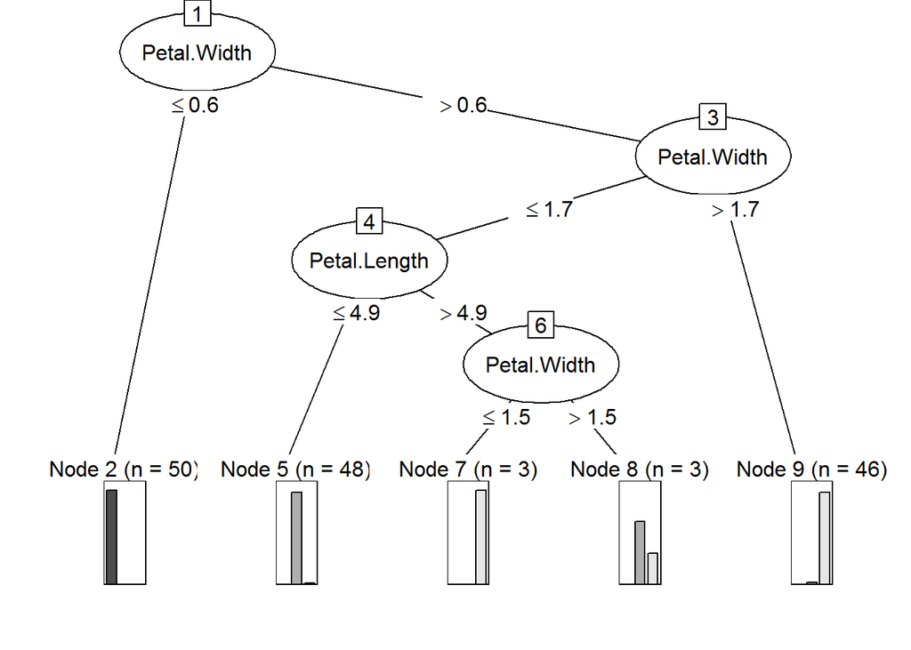

```r
## οπτικοποίηση μέσω του του partykit package
if(require("partykit", quietly = TRUE))   plot(m1)
```

```r
## Χρησιμοποίηση διαφορετικών συνόλων δεδομένων

## J48
DF2 <- read.arff(system.file("arff", "contact-lenses.arff",
                            package = "RWeka"))

m2 <- J48(`contact-lenses` ~ ., data = DF2)

##Εμφάνιση χρήσιμων πληροφοριών
m2
```

```
## J48 pruned tree
## ------------------
##
## tear-prod-rate = reduced: none (12.0)
## tear-prod-rate = normal
## |   astigmatism = no: soft (6.0/1.0)
## |   astigmatism = yes
## |   |   spectacle-prescrip = myope: hard (3.0)
## |   |   spectacle-prescrip = hypermetrope: none (3.0/1.0)
##
## Number of Leaves  :  4
##
## Size of the tree :   7
```

```r
summary(m2) # εδώ πραγματοποιείται χρήση της συνάρτησης evaluate_Weka_classifier()
```

```
##
## === Summary ===
##
## Correctly Classified Instances          22               91.6667 %
## Incorrectly Classified Instances         2                8.3333 %
## Kappa statistic                          0.8447
## Mean absolute error                      0.0833
## Root mean squared error                  0.2041
## Relative absolute error                 22.6257 %
## Root relative squared error             48.1223 %
## Coverage of cases (0.95 level)         100      %
## Mean rel. region size (0.95 level)      45.8333 %
## Total Number of Instances               24
##
## === Confusion Matrix ===
##
##   a  b  c   <-- classified as
##   5  0  0 |  a = soft
##   0  3  1 |  b = hard
##   1  0 14 |  c = none
```

```r
table(DF2$'contact-lenses', predict(m2))
```

```
##
##        soft hard none
##   soft    5    0    0
##   hard    0    3    1
##   none    1    0   14
```

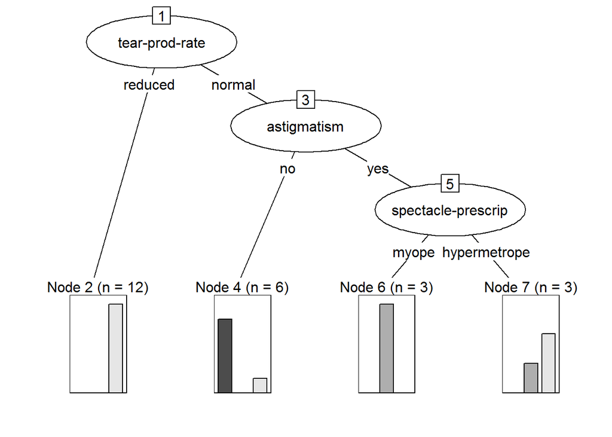

```r
if(require("partykit", quietly = TRUE))    plot(m2)
```

```r
## M5P
DF3 <- read.arff(system.file("arff", "cpu.arff",
                             package = "RWeka"))

m3 <- M5P(class ~ ., data = DF3)
m3
```

```
## M5 pruned model tree:
## (using smoothed linear models)
##
## CHMIN <= 7.5 : LM1 (165/12.903%)
## CHMIN >  7.5 :
## |   MMAX <= 28000 :
## |   |   MMAX <= 13240 :
## |   |   |   CACH <= 81.5 : LM2 (6/18.551%)
## |   |   |   CACH >  81.5 : LM3 (4/30.824%)
## |   |   MMAX >  13240 : LM4 (11/24.185%)
## |   MMAX >  28000 : LM5 (23/48.302%)
##
## LM num: 1
## class =
##  -0.0055 * MYCT
##  + 0.0013 * MMIN
##  + 0.0029 * MMAX
##  + 0.8007 * CACH
##  + 0.4015 * CHMAX
##  + 11.0971
##
## LM num: 2
## class =
##  -1.0307 * MYCT
##  + 0.0086 * MMIN
##  + 0.0031 * MMAX
##  + 0.7866 * CACH
##  - 2.4503 * CHMIN
##  + 1.1597 * CHMAX
##  + 70.8672
##
## LM num: 3
## class =
##  -1.1057 * MYCT
##  + 0.0086 * MMIN
##  + 0.0031 * MMAX
##  + 0.7995 * CACH
##  - 2.4503 * CHMIN
##  + 1.1597 * CHMAX
##  + 83.0016
##
## LM num: 4
## class =
##  -0.8813 * MYCT
##  + 0.0086 * MMIN
##  + 0.0031 * MMAX
##  + 0.6547 * CACH
##  - 2.3561 * CHMIN
##  + 1.1597 * CHMAX
##  + 82.5725
##
## LM num: 5
## class =
##  -0.4882 * MYCT
##  + 0.0218 * MMIN
##  + 0.003 * MMAX
##  + 0.3865 * CACH
##  - 1.3252 * CHMIN
##  + 3.3671 * CHMAX
##  - 51.8474
##
## Number of Rules : 5
```

```r
summary(m3) # εδώ πραγματοποιείται χρήση της συνάρτησης evaluate_Weka_classifier()
```

```
##
## === Summary ===
##
## Correlation coefficient                  0.9728
## Mean absolute error                     21.9246
## Root mean squared error                 37.5095
## Relative absolute error                 22.8582 %
## Root relative squared error             23.3784 %
## Total Number of Instances              209
```

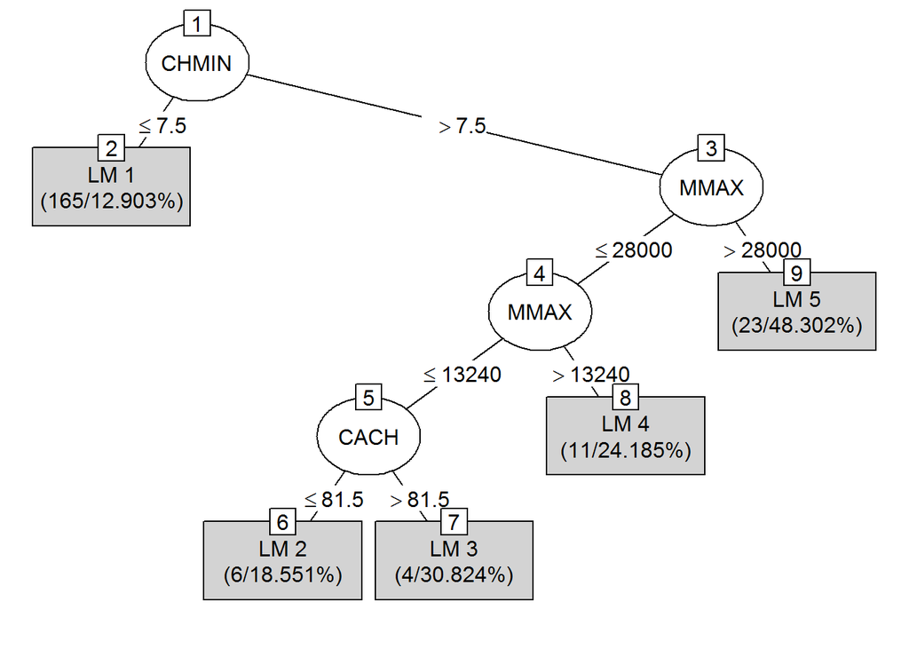

```r
# table(DF3$'class', predict(m3)) # παράλειψη λόγω μεγέθους

if(require("partykit", quietly = TRUE))  plot(m3)
```

```r
## Logistic Model Tree.
DF4 <- read.arff(system.file("arff", "weather.arff",
                             package = "RWeka"))

m4 <- LMT(play ~ ., data = DF4)
m4
```

```
## Logistic model tree
## ------------------
## : LM_1:11/11 (14)
##
## Number of Leaves  :  1
##
## Size of the Tree :   1
## LM_1:
## Class 0 :
## 6.95 +
## [outlook=sunny] * -0.65 +
## [outlook=overcast] * 2.82 +
## [temperature] * -0.02 +
## [humidity] * -0.06 +
## [windy] * -1.38
##
## Class 1 :
## -6.95 +
## [outlook=sunny] * 0.65 +
## [outlook=overcast] * -2.82 +
## [temperature] * 0.02 +
## [humidity] * 0.06 +
## [windy] * 1.38
```

```r
table(DF4$play, predict(m4))
```

```
##
##       yes no
##   yes   8  1
##   no    1  4
```

```r
summary(m4) # εδώ πραγματοποιείται χρήση της συνάρτησης evaluate_Weka_classifier()
```

```
##
## === Summary ===
##
## Correctly Classified Instances          12               85.7143 %
## Incorrectly Classified Instances         2               14.2857 %
## Kappa statistic                          0.6889
## Mean absolute error                      0.2176
## Root mean squared error                  0.3239
## Relative absolute error                 46.8585 %
## Root relative squared error             67.5433 %
## Coverage of cases (0.95 level)         100      %
## Mean rel. region size (0.95 level)      82.1429 %
## Total Number of Instances               14
##
## === Confusion Matrix ===
##
##  a b   <-- classified as
##  8 1 | a = yes
##  1 4 | b = no
```

```r
## Επίδειξη ενός μεγαλύτερης κλίμακας παραδείγματος το οποίο απαιτεί κλάδεμα

if(require("mlbench", quietly = TRUE)
   && require("partykit", quietly = TRUE)) {

## Πρόβλεψη της κλάσης περί ύπαρξης ή όχι διαβήτη για Pima Ινδιάνες

    data("PimaIndiansDiabetes", package = "mlbench")

## Ταίριασμα ενός J48 δένδρου με μειωμένο σφάλμα κλαδέματος

    m5 <- J48(diabetes ~ ., data = PimaIndiansDiabetes,
          control = Weka_control(R = TRUE))

## plot(m5)
## αποφυγή σχεδιασμού τόσο μεγάλων δένδρων χωρίς να παραμετροποιηθεί για την οθόνη του εκάστοτε χρήση
                                          }
```

#### Στο επόμενο χωρίο εξετάζεται η διαδικασία συσταδοποίησης

##### Επιλέχθηκαν και παρουσιάζονται οι SimpleKMeans και FarthestFirst συσταδοποιητές.

```r
# Δίνεται σαν όρισμα και στις 2 περιπτώσεις το -Ν το οποίο αποτελεί το πλήθος των διαφορετικών συστάδων

# SimpleKMeans
cl1 <- SimpleKMeans(iris[, -5], Weka_control(N = 3))

cl1
```

```
##
## kMeans
## ======
##
## Number of iterations: 6
## Within cluster sum of squared errors: 6.982216473785234
##
## Initial starting points (random):
##
## Cluster 0: 6.1,2.9,4.7,1.4
## Cluster 1: 6.2,2.9,4.3,1.3
## Cluster 2: 6.9,3.1,5.1,2.3
##
## Missing values globally replaced with mean/mode
##
## Final cluster centroids:
##                             Cluster#
## Attribute       Full Data          0          1          2
##                   (150.0)     (61.0)     (50.0)     (39.0)
## ==========================================================
## Sepal.Length       5.8433     5.8885      5.006     6.8462
## Sepal.Width        3.0573     2.7377      3.428     3.0821
## Petal.Length        3.758     4.3967      1.462     5.7026
## Petal.Width        1.1993      1.418      0.246     2.0795
```

```r
table(predict(cl1), iris$Species)
```

```
##
##     setosa versicolor virginica
##   0      0         47        14
##   1     50          0         0
##   2      0          3        36
```

```r
# FartherFirst
cl2 <- FarthestFirst(iris[, -5],  Weka_control(N = 3))

cl2
```

```
##
## FarthestFirst
## ==============
##
## Cluster centroids:
##
## Cluster 0
##   7.7 3.0 6.1 2.3
## Cluster 1
##   4.3 3.0 1.1 0.1
## Cluster 2
##   4.9 2.5 4.5 1.7
```

```r
table(predict(cl2), iris$Species)
```

```
##
##     setosa versicolor virginica
##   0      0          6        35
##   1     50          0         0
##   2      0         44        15
```

#### Επιπλέον εξετάζεται η διαδικασία ενημέρωσης του χρήση για τις διαθέσιμες επιλογές των ταξινομητών και των διαφόρων στοιχείων του Weka

```r
## Ερώητηση για τις επιλογές του J48
WOW("J48")
```

```
## -U      Use unpruned tree.
## -O      Do not collapse tree.
## -C <pruning confidence>
##         Set confidence threshold for pruning.  (default 0.25)
##  Number of arguments: 1.
## -M <minimum number of instances>
##         Set minimum number of instances per leaf.  (default 2)
##  Number of arguments: 1.
## -R      Use reduced error pruning.
## -N <number of folds>
##         Set number of folds for reduced error pruning. One fold is
##         used as pruning set.  (default 3)
##  Number of arguments: 1.
## -B      Use binary splits only.
## -S      Do not perform subtree raising.
## -L      Do not clean up after the tree has been built.
## -A      Laplace smoothing for predicted probabilities.
## -J      Do not use MDL correction for info gain on numeric
##         attributes.
## -Q <seed>
##         Seed for random data shuffling (default 1).
##  Number of arguments: 1.
## -doNotMakeSplitPointActualValue
##         Do not make split point actual value.
## -output-debug-info
##         If set, classifier is run in debug mode and may output
##         additional info to the console
## -do-not-check-capabilities
##         If set, classifier capabilities are not checked before
##         classifier is built (use with caution).
```

```r
## Εκπαίδευση ενός j48 δένδρου για το σύνολο δεδομένων iris
J48(Species ~ ., data = iris)
```

```
## J48 pruned tree
## ------------------
##
## Petal.Width <= 0.6: setosa (50.0)
## Petal.Width > 0.6
## |   Petal.Width <= 1.7
## |   |   Petal.Length <= 4.9: versicolor (48.0/1.0)
## |   |   Petal.Length > 4.9
## |   |   |   Petal.Width <= 1.5: virginica (3.0)
## |   |   |   Petal.Width > 1.5: versicolor (3.0/1.0)
## |   Petal.Width > 1.7: virginica (46.0/1.0)
##
## Number of Leaves  :  5
##
## Size of the tree :   9
```

```r
## Εκπαίδευση ενός j48 δένδρου για το σύνολο δεδομένων iris με την επιλογή
## reduced error pruning (-R) και το minimum number of instances να έχει οριστεί ίσο με 5 (-M 5)
J48(Species ~ ., data = iris, control = Weka_control(R = TRUE, M = 5))
```

```
## J48 pruned tree
## ------------------
##
## Petal.Width <= 0.6: setosa (34.0)
## Petal.Width > 0.6
## |   Petal.Width <= 1.5: versicolor (32.0/1.0)
## |   Petal.Width > 1.5: virginica (34.0/2.0)
##
## Number of Leaves  :  3
##
## Size of the tree :   5
```

#### Στη συνέχεια παρουσιάζεται η διαδικασία κλήσης και χρήσης των φίλτρων του Weka

```r
## Διάβασμα του συνόλου δεδομένων weather
w <- read.arff(system.file("arff","weather.arff",
                  package = "RWeka"))

## Κανονικοποίηση - Normalize (response irrelevant)
m1 <- Normalize( ~ . , data = w )
m1
```

```
##     outlook temperature  humidity windy play
## 1     sunny  1.00000000 0.6451613 FALSE   no
## 2     sunny  0.76190476 0.8064516  TRUE   no
## 3  overcast  0.90476190 0.6774194 FALSE  yes
## 4     rainy  0.28571429 1.0000000 FALSE  yes
## 5     rainy  0.19047619 0.4838710 FALSE  yes
## 6     rainy  0.04761905 0.1612903  TRUE   no
## 7  overcast  0.00000000 0.0000000  TRUE  yes
## 8     sunny  0.38095238 0.9677419 FALSE   no
## 9     sunny  0.23809524 0.1612903 FALSE  yes
## 10    rainy  0.52380952 0.4838710 FALSE  yes
## 11    sunny  0.52380952 0.1612903  TRUE  yes
## 12 overcast  0.38095238 0.8064516  TRUE  yes
## 13 overcast  0.80952381 0.3225806 FALSE  yes
## 14    rainy  0.33333333 0.8387097  TRUE   no
```

```r
## Διακριτοποίηση - Discretize
m2 <- Discretize(play ~., data = w)
m2
```

```
##     outlook temperature humidity windy play
## 1     sunny       'All'    'All' FALSE   no
## 2     sunny       'All'    'All'  TRUE   no
## 3  overcast       'All'    'All' FALSE  yes
## 4     rainy       'All'    'All' FALSE  yes
## 5     rainy       'All'    'All' FALSE  yes
## 6     rainy       'All'    'All'  TRUE   no
## 7  overcast       'All'    'All'  TRUE  yes
## 8     sunny       'All'    'All' FALSE   no
## 9     sunny       'All'    'All' FALSE  yes
## 10    rainy       'All'    'All' FALSE  yes
## 11    sunny       'All'    'All'  TRUE  yes
## 12 overcast       'All'    'All'  TRUE  yes
## 13 overcast       'All'    'All' FALSE  yes
## 14    rainy       'All'    'All'  TRUE   no
```

#### Τέλος, αξίζει να αναφερθεί πως παρέχεται η δυνατότητα δημιουργίας διεπαφών από τον ίδιο το χρήση προς αντικέιμενα του Weka

```r
## Δημιουργια διεπαφής προς τον ταξινομητή Naive Bayes του Weka
NB <- make_Weka_classifier("weka/classifiers/bayes/NaiveBayes")

## Μέθοδος εκτύπωσης της διεπαφής (print method)
NB
```

```
## An R interface to Weka class 'weka.classifiers.bayes.NaiveBayes',
## which has information
##
##   Class for a Naive Bayes classifier using estimator classes.
##   Numeric estimator precision values are chosen based on analysis
##   of the training data. For this reason, the classifier is not an
##   UpdateableClassifier (which in typical usage are initialized
##   with zero training instances) -- if you need the
##   UpdateableClassifier functionality, use the NaiveBayesUpdateable
##   classifier. The NaiveBayesUpdateable classifier will use a
##   default precision of 0.1 for numeric attributes when
##   buildClassifier is called with zero training instances.
##
##   For more information on Naive Bayes classifiers, see
##
##   George H. John, Pat Langley: Estimating Continuous Distributions
##   in Bayesian Classifiers. In: Eleventh Conference on Uncertainty
##   in Artificial Intelligence, San Mateo, 338-345, 1995.
##
##   BibTeX:
##
##   @INPROCEEDINGS{John1995,
##     year = {1995},
##     author = {George H. John and Pat Langley},
##     pages = {338-345},
##     address = {San Mateo},
##     publisher = {Morgan Kaufmann},
##     booktitle = {Eleventh Conference on Uncertainty in Artificial
##       Intelligence},
##     title = {Estimating Continuous Distributions in Bayesian
##       Classifiers},
##   }
##
## Argument list:
##   x(formula, data, subset, na.action, control = Weka_control(),
##   options = NULL)
##
## Returns objects inheriting from classes:
##   Weka_classifier
```

```r
## Χρήση του Weka Option Wizard για περισσότερες πληροφορίες
WOW(NB)
```

```
## -K      Use kernel density estimator rather than normal
##         distribution for numeric attributes
## -D      Use supervised discretization to process numeric
##         attributes
## -O      Display model in old format (good when there are many
##         classes)
## -output-debug-info
##         If set, classifier is run in debug mode and may output
##         additional info to the console
## -do-not-check-capabilities
##         If set, classifier capabilities are not checked before
##         classifier is built (use with caution).
```

```r
## Παράδειγμα χρήσης της διεπαφής
if(require("e1071", quietly = TRUE) &&
require("mlbench", quietly = TRUE)) {

                data("HouseVotes84", package = "mlbench")
                model <- NB(Class ~ ., data = HouseVotes84)

                predict(model, HouseVotes84[1:10, -1])
                predict(model, HouseVotes84[1:10, -1], type = "prob")

                                    }
```

```
##        democrat   republican
## 1  1.361394e-07 9.999999e-01
## 2  6.699596e-08 9.999999e-01
## 3  2.250184e-03 9.977498e-01
## 4  9.929477e-01 7.052312e-03
## 5  8.221067e-01 1.778933e-01
## 6  4.901860e-01 5.098140e-01
## 7  1.036287e-04 9.998964e-01
## 8  7.224667e-06 9.999928e-01
## 9  9.454311e-08 9.999999e-01
## 10 1.000000e+00 7.070261e-10
```